# lab10

Khudoyarova Anastasia

12/29/2020

# Загрузка

```r
df <- read.table("jj.dat",
           header=FALSE, col.names = c('EPS'))
df <- cbind(date = rownames(df), df)
rownames(df) <- NULL
head(df)
```

```
##   date  EPS
## 1    1 0.71
## 2    2 0.63
## 3    3 0.85
## 4    4 0.44
## 5    5 0.61
## 6    6 0.69
```

## a. After obtaining a copy of the dataset, plot the quarterly EPS vs. time. Describe any patterns that you observe.

Тут мы видим рост, причем рост идет по экспоненте. Данные не могут называться стационарными

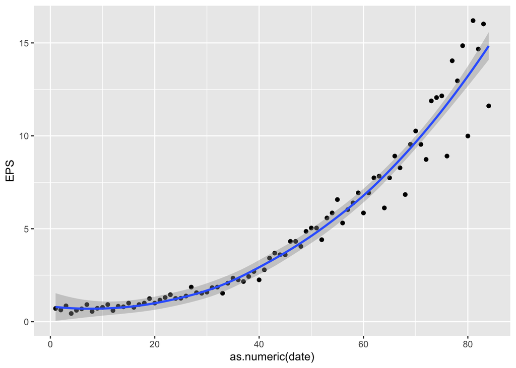

```r
ggplot(data = df, aes(x=as.numeric(date), y=EPS)) + geom_point() +
  geom_smooth(method = "loess", formula = y ~ x)
```

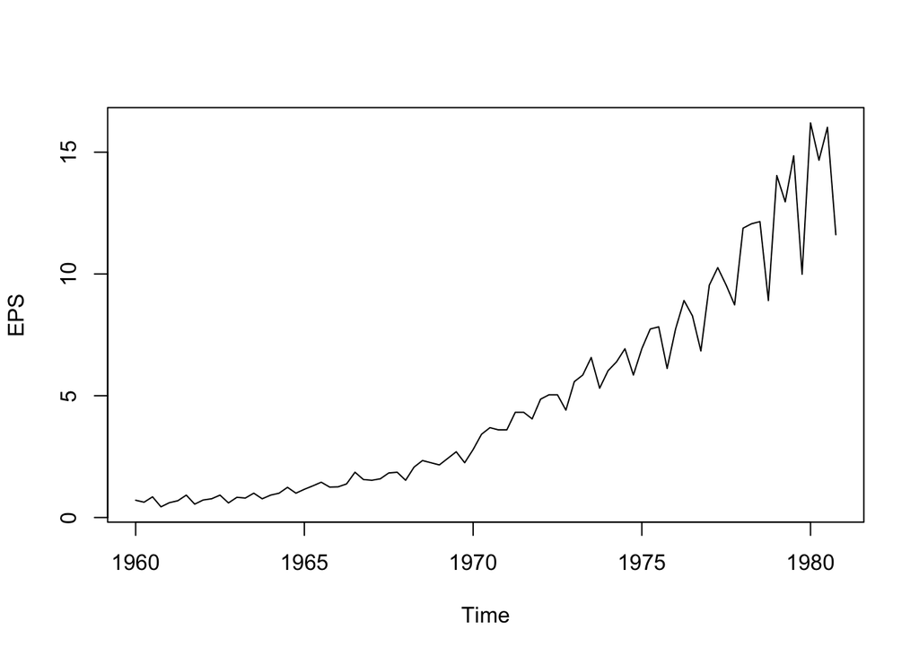

```r
df$times <- ts(df$EPS, start=1960, frequency=4)
plot(df$times, xlab = "Time", ylab = "EPS")
```

## b. In order to perform an ARIMA model, the time series will need to be transformed to remove any trend. Plot the difference of xt and xt-1, for all t > 0.

Удаление тренда временного ряда необходимо для того, чтобы убрать все периодические зависимости от времени. Так же получаем взаимосвязи между элементами становятся менее структурированными. Это называется дифференцирование, и позволяет стабилизировать среднее значение временного ряда. Для удаления тренда необходимо взять разность между текущим значением и предыдущим наблюдениями. Инвертирование процесса требуется, когда прогноз должен быть преобразован обратно в исходный масштаб. Взятие разницы между последовательным наблюдениями - lag разница.

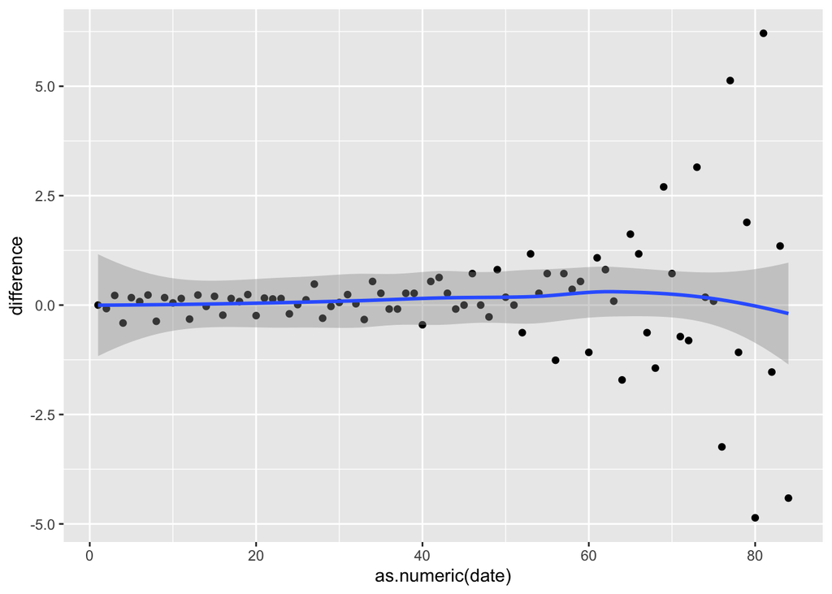

```r
difference <- append(c(0), diff(df$EPS))
ggplot(df, aes(x=as.numeric(date), y=difference)) +
  geom_point() +
  geom_smooth(method = "loess", formula = y ~ x)
```

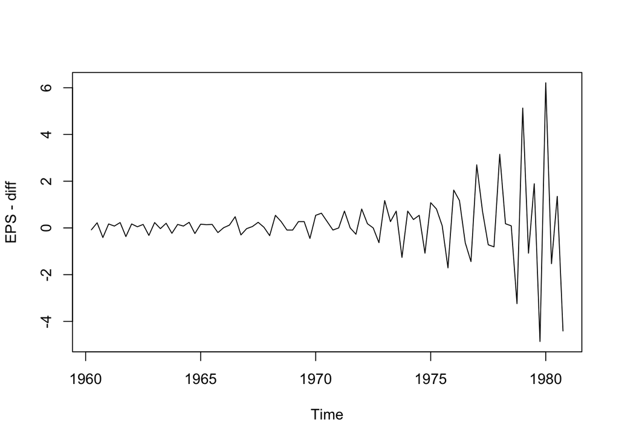

```r
plot(diff(df$times), xlab = "Time",
ylab = "EPS - diff")
```

Has this difference adequately detrended the series? Нет Does the variability of the EPS appear constant over time? Why does the constant variance matter? не константа постоянно

## c. Plot the log10 of the quarterly EPS vs. time and plot the difference of log10(xt ) and log10(xt-1) for all t > 0. Has this adequately detrended the series? Has the variability of the differenced log10(EPS) become more constant?

Тут мы видим разброс стал не таким сильным. Данные стали более нормализованными

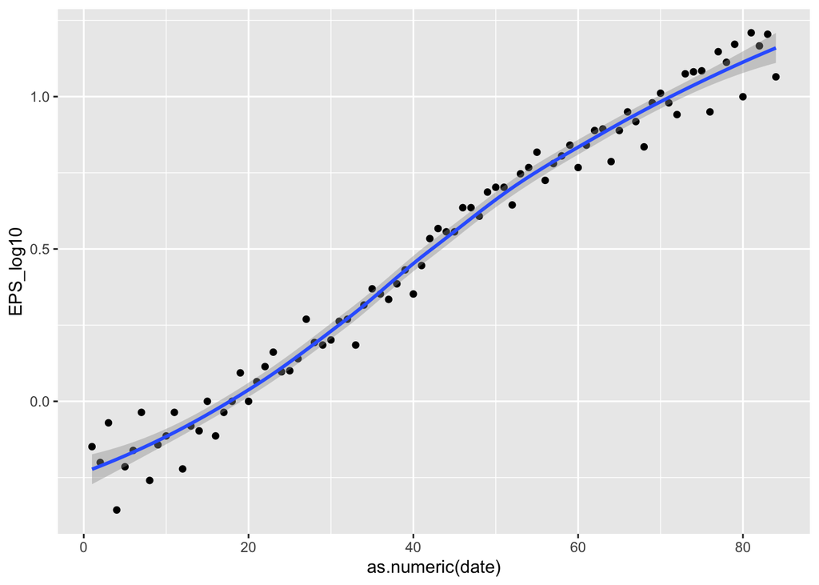

```r
df$EPS_log10 <- log10(df$EPS)

ggplot(df, aes(x=as.numeric(date), y=EPS_log10)) +
  geom_point() +
  geom_smooth(method = "loess", formula = y ~ x)
```

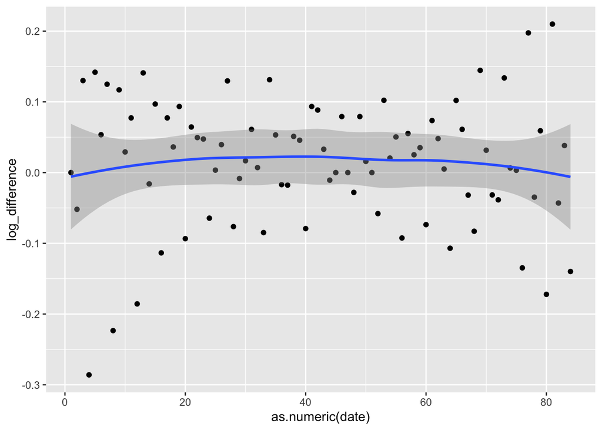

```r
log_difference <- append(c(0), diff(df$EPS_log10))

ggplot(df, aes(x=as.numeric(date), y=log_difference)) +
  geom_point() +
  geom_smooth(method = "loess", formula = y ~ x)
```

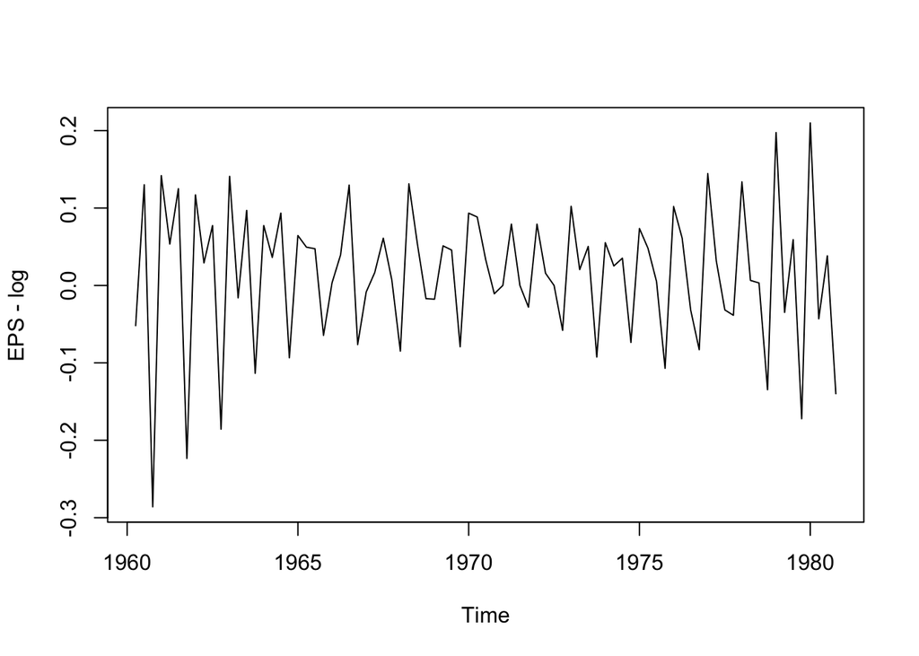

```r
plot(diff(log10(df$times)), xlab = "Time",
ylab = "EPS - log")
```

## d. Treating the differenced log10 of the EPS series as a stationary series, plot the ACF and PACF of this series. What possible ARIMA models would you consider and why?

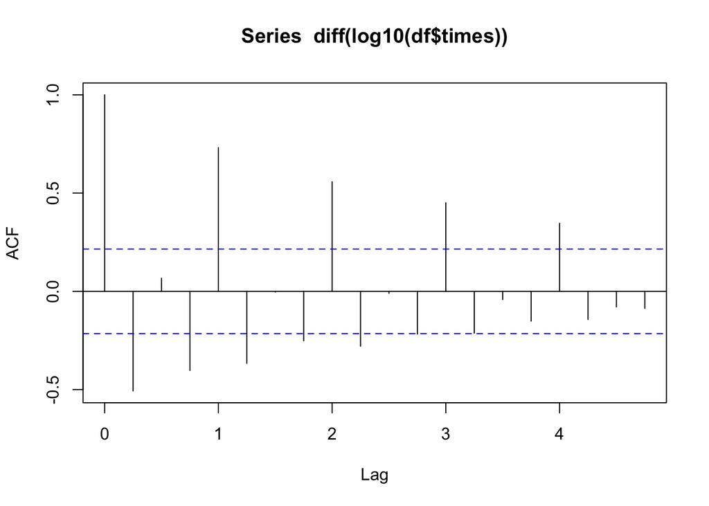

```r
acf(diff(log10(df$times)))
```

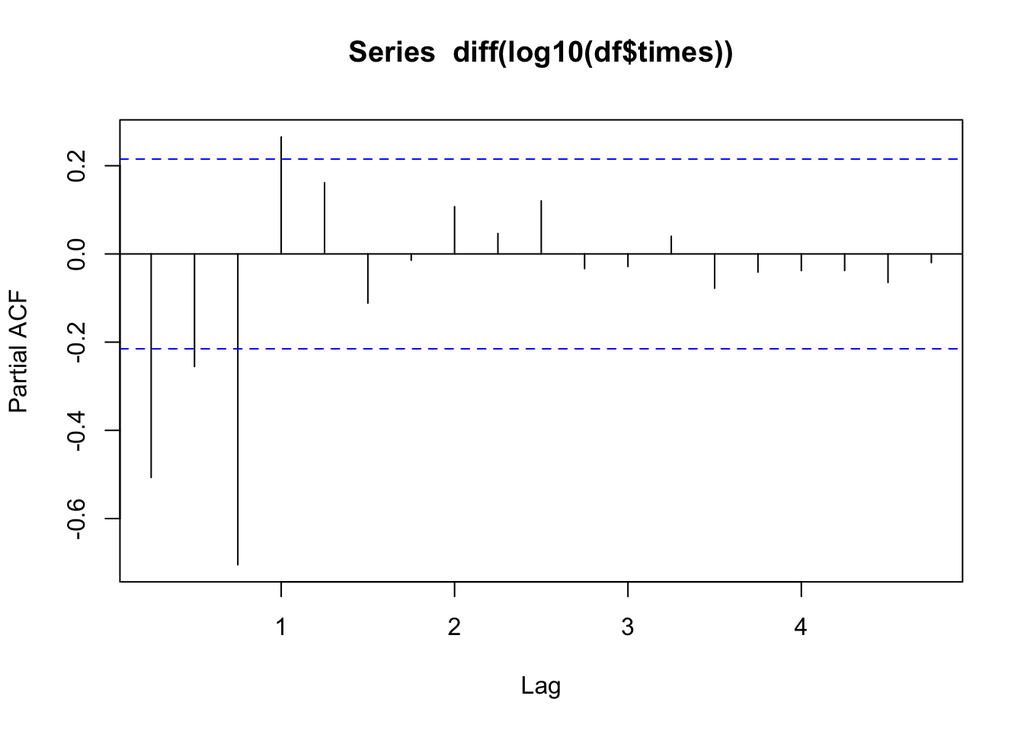

```r
pacf(diff(log10(df$times)))
```

## e. Run the proposed ARIMA models from part d and compare the results. Identify an appropriate model. Justify your choice.

Таким образом строим с использованием ARIMA:

```r
arima_1 <- Arima(log10(df$times), order=c(1,0,0))
arima_1
```

```
## Series: log10(df$times)
## ARIMA(1,0,0) with non-zero mean
##
## Coefficients:
##          ar1    mean
##       0.9843  0.4686
## s.e.  0.0160  0.4035
##
## sigma^2 estimated as 0.008605:  log likelihood=79.81
## AIC=-153.62   AICc=-153.32   BIC=-146.33
```

```r
arima_1 <- Arima(log10(df$times), order=c(2,0,0))
arima_1
```

```
## Series: log10(df$times)
## ARIMA(2,0,0) with non-zero mean
##
## Coefficients:
##          ar1     ar2    mean
##       0.5244  0.4692  0.4720
## s.e.  0.0972  0.0977  0.5446
##
## sigma^2 estimated as 0.006802:  log likelihood=89.82
## AIC=-171.65   AICc=-171.14   BIC=-161.92
```

```r
arima_1 <- Arima(log10(df$times), order=c(3,0,2))
arima_1
```

```
## Series: log10(df$times)
## ARIMA(3,0,2) with non-zero mean
##
## Coefficients:
##           ar1     ar2     ar3     ma1     ma2    mean
##       -0.7592  0.9808  0.7498  1.7982  0.8689  0.4667
## s.e.   0.1611  0.0187  0.1616  0.1488  0.1410  0.5079
##
## sigma^2 estimated as 0.005534:  log likelihood=98.61
## AIC=-183.21   AICc=-181.74   BIC=-166.2
```

#4.9

Логарифм иногда может исказить данные. в таком случае применяют транформацию по проще - находят разницу между данными по сезонности

#4.10

Для одинаковых данных variance будет равен 1

#4.11 AR(p), p=1,2,3,4

Возьмем коэффициенты от уравнения 0.78, -0.45, 0.1, -0.33 и запустим моделирование на 10000

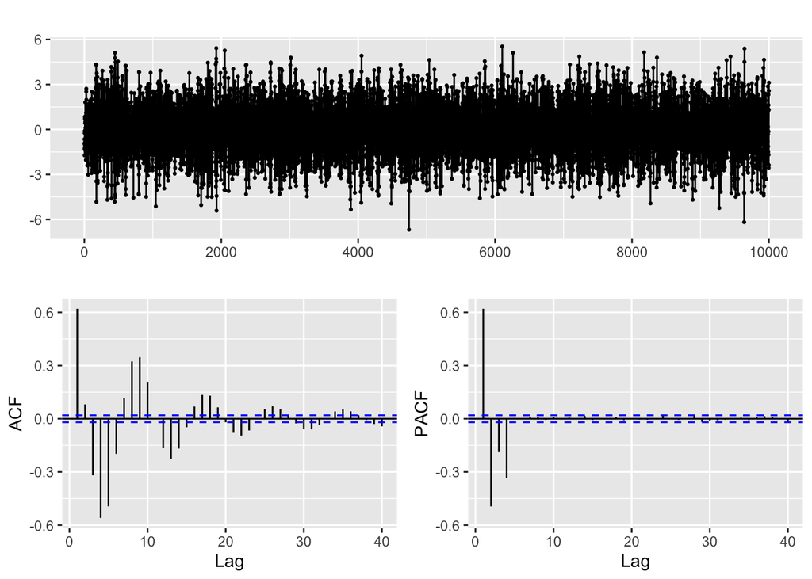

```r
ts.sim_AR4 <- arima.sim(n = 10000, list(ar = c(0.78, -0.45, 0.1, -0.33)))
ggtsdisplay(ts.sim_AR4)
```

ACF похожа на синусоиду и мы явно видим тут повторения. Пик - 4

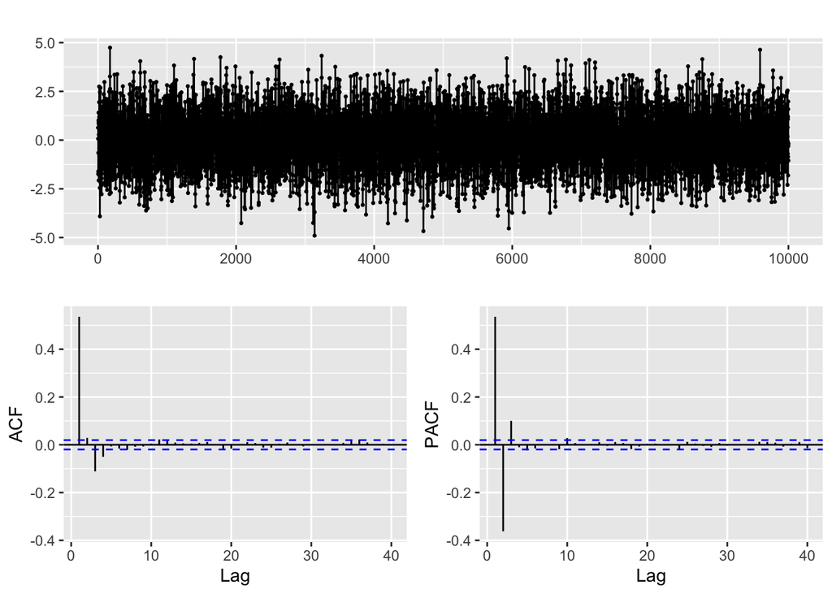

```r
ts.sim_AR3 <- arima.sim(n = 10000, list(ar = c(0.78, -0.45, 0.1)))
ggtsdisplay(ts.sim_AR3)
```

Пик тройка

Тут уже остаются выбросы

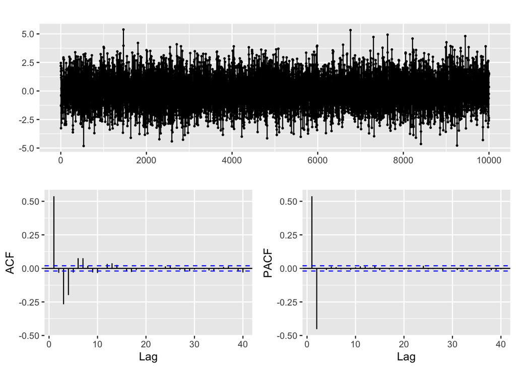

```r
ts.sim_AR2 <- arima.sim(n = 10000, list(ar = c(0.78, -0.45)))
ggtsdisplay(ts.sim_AR2)
```

Пик - 2

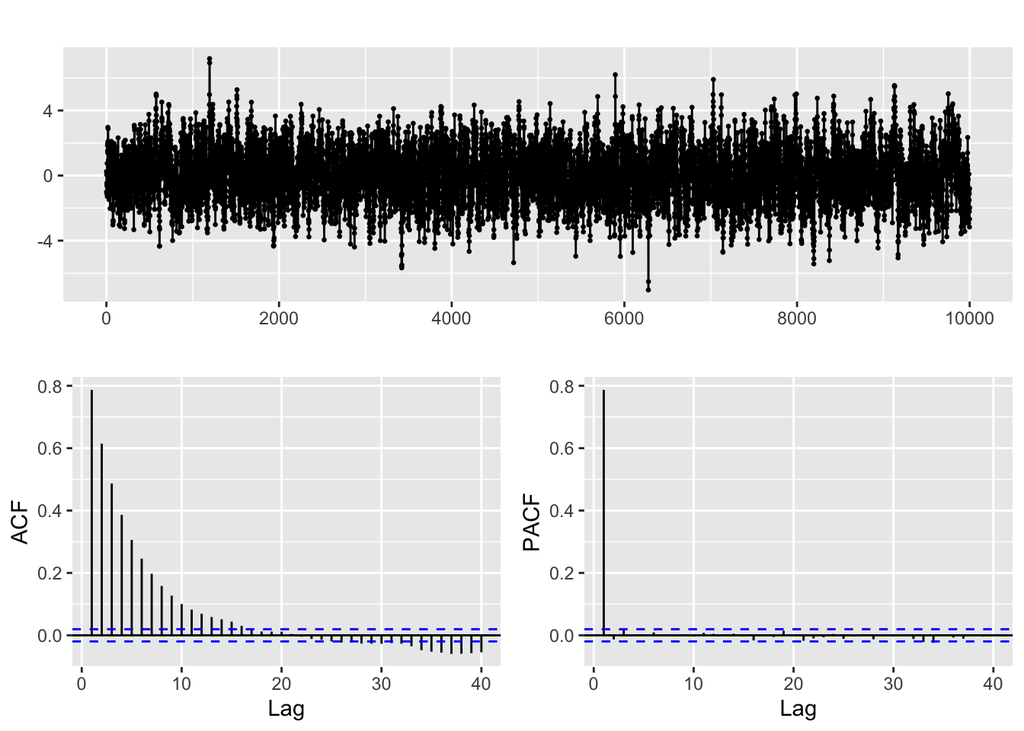

```r
ts.sim_AR1 <- arima.sim(n = 10000, list(ar = c(0.78)))
ggtsdisplay(ts.sim_AR1)
```

И наконец последнее - показывает нам плавный спуск - пик 1

#4.12 MA(q) q=1,2,3,4

Возьмем коэффициенты 1.78, -1.45, 1.1, -1.33

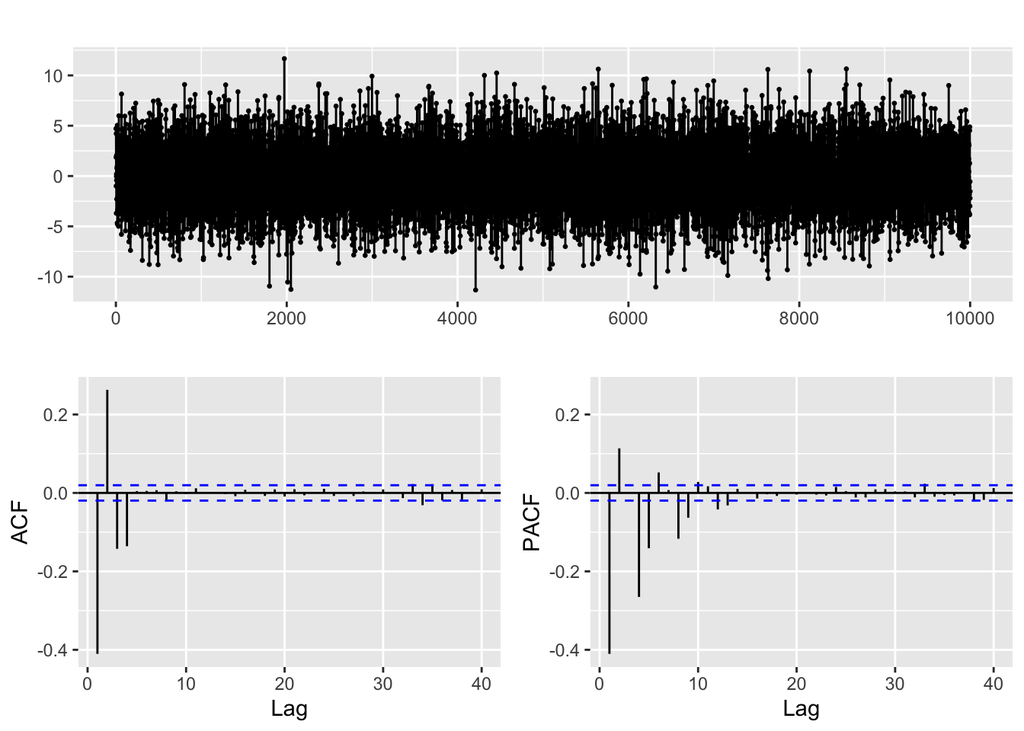

```r
sim_MA4 <- arima.sim(n = 10000, list( ma = c(1.78, -1.45, 1.1, -1.33)))
ggtsdisplay(sim_MA4)
```

Отчетливо видны пики на ACF и PACF

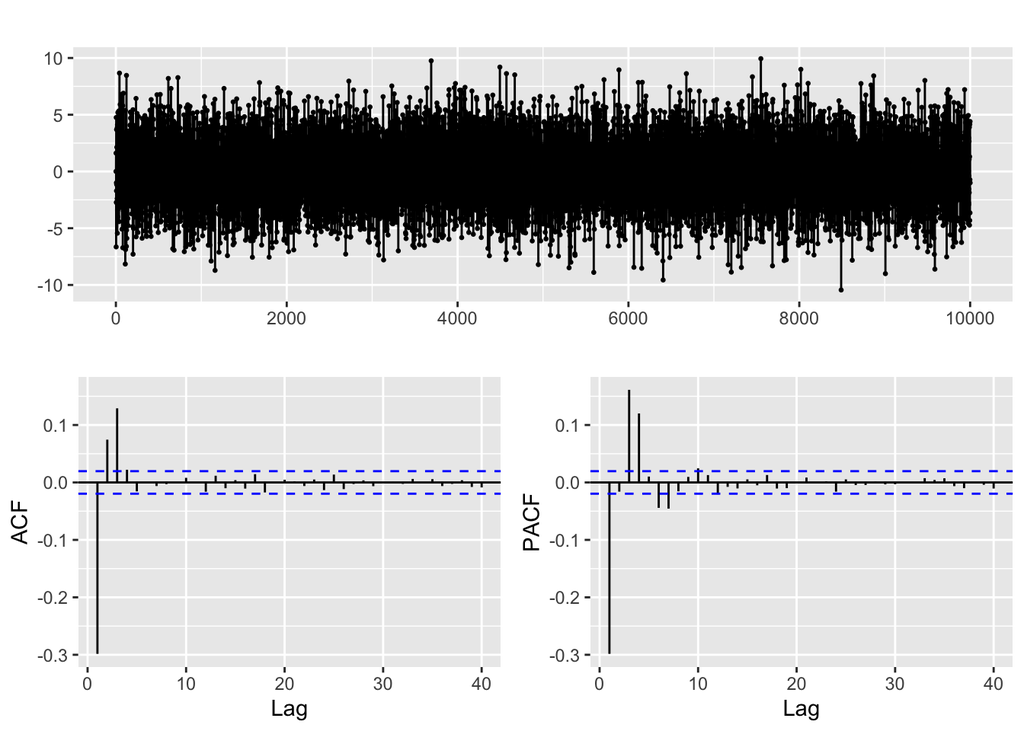

```r
sim_MA3 <- arima.sim(n = 10000, list( ma = c(1.78, -1.45, 1.1)))
ggtsdisplay(sim_MA3)
```

Так же видим пик на 3 позиции

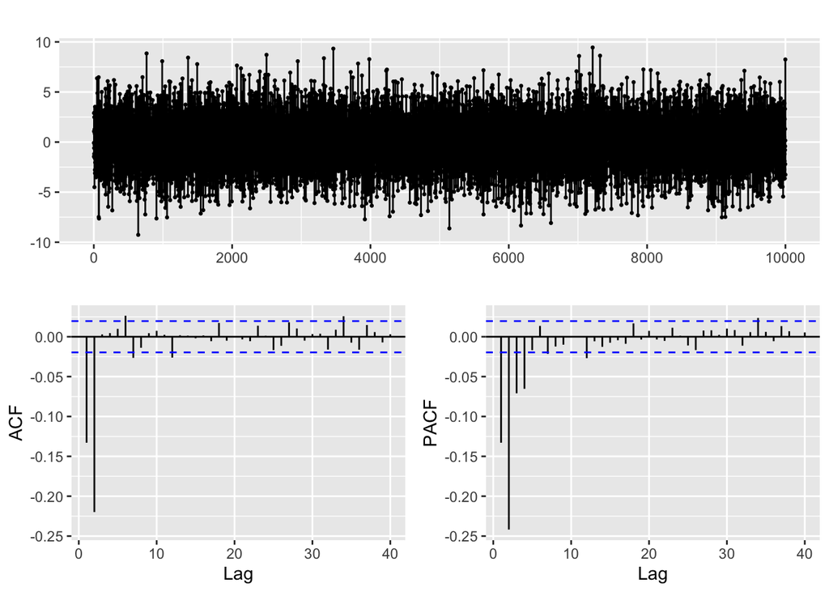

```r
sim_MA2 <- arima.sim(n = 10000, list( ma = c(1.78, -1.45)))
ggtsdisplay(sim_MA2)
```

Пик на второй

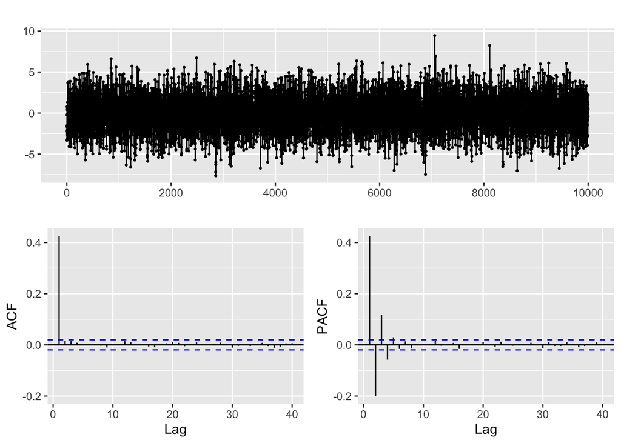

```r
sim_MA1 <- arima.sim(n = 10000, list( ma = c(1.78)))
ggtsdisplay(sim_MA1)
```

И единица